# Data Translation Project

Amanda Dang

6/10/2022

```r
library(dplyr)
library(lubridate)
```

```r
library(ggplot2)
load('king_dailyvisits_load.Rdata')
dv %>%
  arrange(brands, naics_title, date) %>%
  tail()
```

```
##             date naics_code           naics_title brands visits_by_day
## 37009 2020-07-26     451110 Sporting Goods Stores Zumiez            59
## 37010 2020-07-27     451110 Sporting Goods Stores Zumiez            53
## 37011 2020-07-28     451110 Sporting Goods Stores Zumiez            61
## 37012 2020-07-29     451110 Sporting Goods Stores Zumiez            56
## 37013 2020-07-30     451110 Sporting Goods Stores Zumiez            72
## 37014 2020-07-31     451110 Sporting Goods Stores Zumiez            69
```

```r
dv <- dv %>% mutate(naics_two_digit = floor(naics_code/10000))
dv <- dv %>% mutate(naics_four_digit = floor(naics_code/100))
dv$weekday <- wday(dv$date, label=TRUE)

load('king_originvisits_load.Rdata')
ov %>%
  select(GEOID, naics_code, naics_title, brands, visits) %>%
  filter(brands != '') %>%
  head()
```

```
##          GEOID naics_code            naics_title             brands visits
## 1 530330073003     236118 Residential Remodelers California Closets      6
## 2 530330247013     236118 Residential Remodelers California Closets      8
## 3 530330233001     236118 Residential Remodelers California Closets      7
## 4 530330239003     236118 Residential Remodelers California Closets      4
## 5 530530723082     236118 Residential Remodelers California Closets      4
## 6 530610518033     236118 Residential Remodelers California Closets      4
```

```r
load('neighborhood_names.Rdata')
ov %>%
  right_join(neighborhood_names) %>%
  tail()
```

```
##       naics_code                                              naics_title
## 30996     926120 Regulation and Administration of Transportation Programs
## 30997     926120 Regulation and Administration of Transportation Programs
## 30998     928120                                    International Affairs
## 30999     928120                                    International Affairs
## 31000     928120                                    International Affairs
## 31001     928120                                    International Affairs
##       brands        GEOID visits NEIGHBORHOOD_DISTRICT_NAME
## 30996        530330106002      4                  Southwest
## 30997        530330099003      4     Delridge Neighborhoods
## 30998        530330265001      4     Delridge Neighborhoods
## 30999        530330041002      4                  Northeast
## 31000        530330117004      4           Greater Duwamish
## 31001        530330066002      4                 Lake Union
```

```r
dv %>%
  group_by(naics_title) %>%
  summarise(Total_Visits = sum(visits_by_day)) %>%
  arrange(desc(Total_Visits)) %>% head(10)
```

```
## # A tibble: 10 x 2
##    naics_title                                                 Total_Visits
##    <chr>                                                              <int>
##  1 Lessors of Nonresidential Buildings (except Miniwarehouses)       417370
##  2 Nature Parks and Other Similar Institutions                       349959
##  3 Full-Service Restaurants                                          349655
##  4 Limited-Service Restaurants                                       232464
##  5 Snack and Nonalcoholic Beverage Bars                              183990
##  6 General Medical and Surgical Hospitals                            170698
##  7 Gasoline Stations with Convenience Stores                         147613
##  8 Supermarkets and Other Grocery (except Convenience) Stores        131787
##  9 Other Airport Operations                                          110169
## 10 Fitness and Recreational Sports Centers                            95177
```

Because there was a blank brand, it was dropped from the bar plot so we could see how the top 10 brands compared to each other.

```r
dv %>%
  group_by(brands) %>%
  summarise(Total_Visits = sum(visits_by_day)) %>%
  arrange(desc(Total_Visits)) %>% head(10)
```

```
## # A tibble: 10 x 2
##    brands                   Total_Visits
##    <chr>                           <int>
##  1 ""                            2509323
##  2 "UW Medicine"                  128245
##  3 "Starbucks"                     66575
##  4 "Target"                        43156
##  5 "Costco Wholesale Corp."        42010
##  6 "Safeway"                       38129
##  7 "McDonald's"                    33697
##  8 "The Home Depot"                32292
##  9 "Walmart"                       30287
## 10 "Chevron"                       25350
```

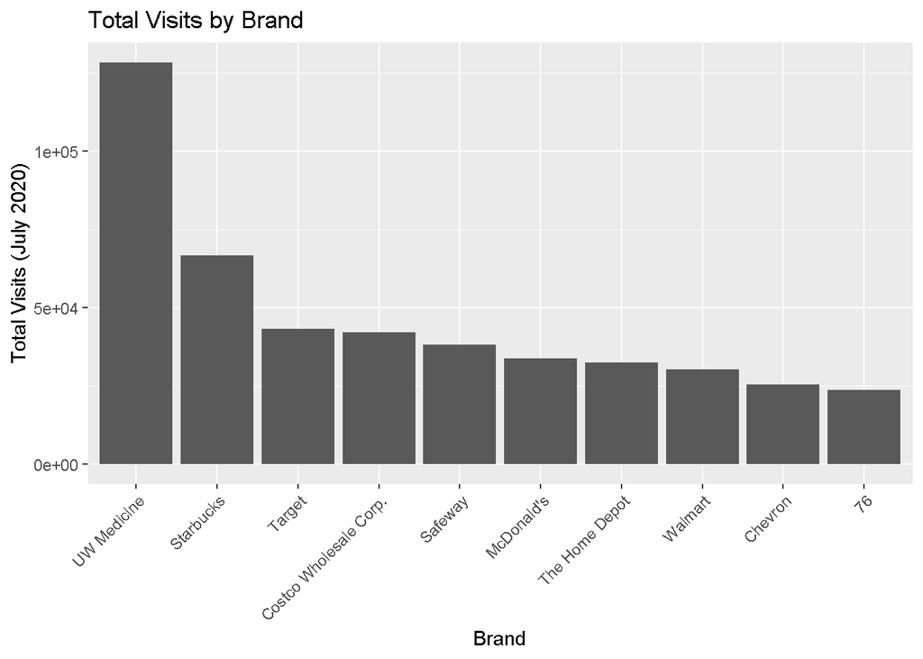

```r
ggplot(dv %>%
  group_by(brands) %>%
  summarise(Total_Visits = sum(visits_by_day)) %>%
  arrange(desc(Total_Visits)) %>% slice(2:11), aes(x = reorder(brands,-Total_Visits), y = Total_Visits)) +
  stat_summary(geom = 'bar',
               fun = sum) +
  labs(x = 'Brand', y = 'Total Visits (July 2020)', title = 'Total Visits by Brand') + theme(axis.text.x=element_text(angle = 45, hjust = 1))
```

```r
 options(scipen=999)
```

To begin, I wanted to see what brands had the highest total visits in July 2020. This gives us a snapshot of the ones that we can further explore. Moving forward, I wanted to look closer at Costco because unlike the other brands in this graph, Costco is the only one that is completely closed on July 4th.

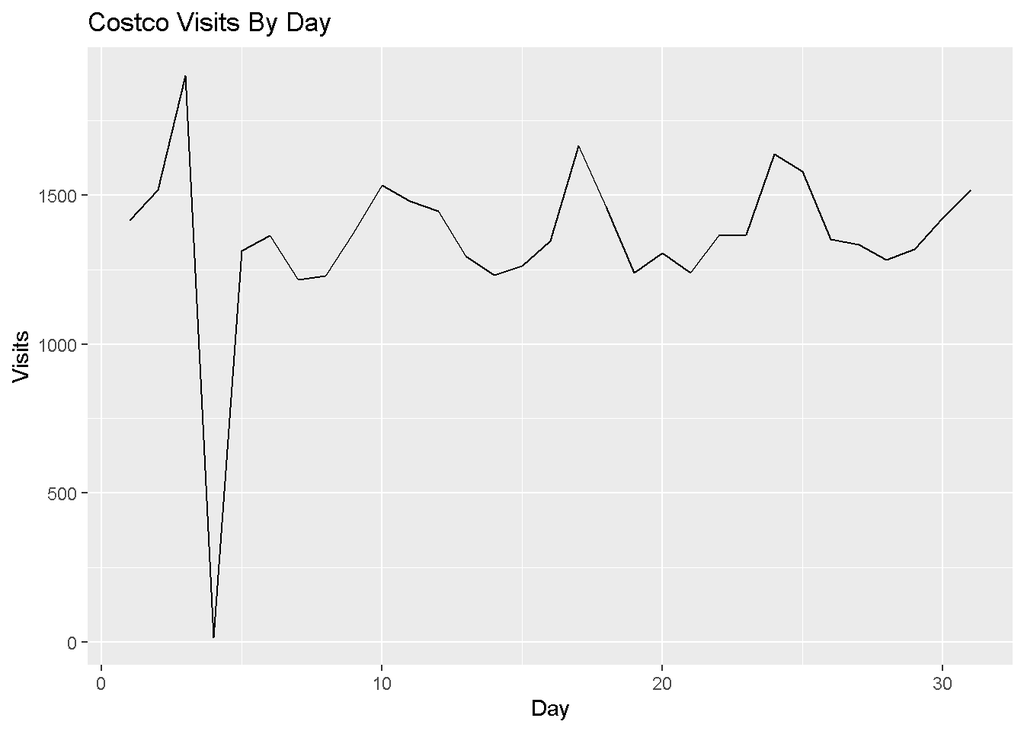

```r
costco <- dv %>%
  filter(brands == "Costco Wholesale Corp.")%>%
  mutate(day= day(date))

ggplot(costco, aes(x=day, y=visits_by_day)) +
  geom_line() +
  labs(title = "Costco Visits By Day",
       y = "Visits", x = "Day")
```

For my next visualization, I wanted to see what the spread of visits looked like throughout the entire month. As I previously mentioned, Costco is closed on July 4th, explaining the sudden drastic dip in our graph.

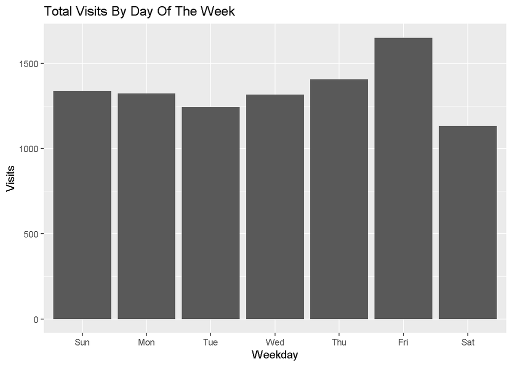

```r
ggplot(costco, aes(x=weekday, y=visits_by_day)) +
  stat_summary(geom = 'bar',
               fun = mean) +
  labs(x = "Weekday", y = "Visits", title = 'Total Visits By Day Of The Week')
```

Taking a closer look at the specific days of the week, we can see how the number of visits vary. However, when looking at the data, we can see that it shows 17 visits on the 4th, but we know that they were closed. This is likely an error in the data or some of the warehouse employees may have possibly been working. For my next bar plot, I will be correcting this.

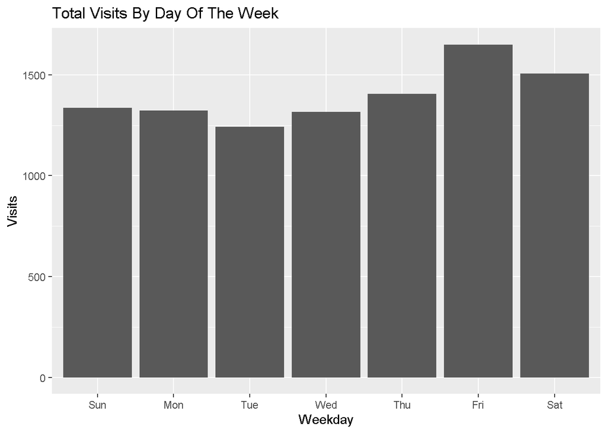

```r
costco <- costco %>% filter(day != 4)
ggplot(costco, aes(x=weekday, y=visits_by_day)) +
  stat_summary(geom = 'bar',
               fun = mean) +
   labs(x = "Weekday", y = "Visits", title = 'Total Visits By Day Of The Week')
```

In this new bar plot, I removed the holiday so we will be looking at the average number of visitors per day. From this, we can see that Friday is by far the busiest day of the week to go to Costco, while Tuesday is the least busy day. Knowing this, if you wanted to avoid the crazy parking and lines at check-out, you would want to visit Costco on Tuesdays.

```r
ov %>%
  right_join(neighborhood_names) %>%
  tail()
```

```
##       naics_code                                              naics_title
## 30996     926120 Regulation and Administration of Transportation Programs
## 30997     926120 Regulation and Administration of Transportation Programs
## 30998     928120                                    International Affairs
## 30999     928120                                    International Affairs
## 31000     928120                                    International Affairs
## 31001     928120                                    International Affairs
##       brands        GEOID visits NEIGHBORHOOD_DISTRICT_NAME
## 30996        530330106002      4                  Southwest
## 30997        530330099003      4     Delridge Neighborhoods
## 30998        530330265001      4     Delridge Neighborhoods
## 30999        530330041002      4                  Northeast
## 31000        530330117004      4           Greater Duwamish
## 31001        530330066002      4                 Lake Union
```

Now, I wanted to see what brands people are visiting through their phones if I were to live in the Northwest.

```r
nw <- ov %>%
  right_join(neighborhood_names) %>%
  filter(NEIGHBORHOOD_DISTRICT_NAME == "Northwest") %>%
  group_by(naics_title) %>%
  summarise(visits=sum(visits)) %>%
  arrange(desc(visits))
nw
```

```
## # A tibble: 181 x 2
##    naics_title                                                 visits
##    <chr>                                                        <dbl>
##  1 Full-Service Restaurants                                      2937
##  2 Snack and Nonalcoholic Beverage Bars                          2008
##  3 Nature Parks and Other Similar Institutions                   1932
##  4 Limited-Service Restaurants                                   1750
##  5 Lessors of Nonresidential Buildings (except Miniwarehouses)   1472
##  6 Fitness and Recreational Sports Centers                        960
##  7 Gasoline Stations with Convenience Stores                      937
##  8 Supermarkets and Other Grocery (except Convenience) Stores     903
##  9 General Medical and Surgical Hospitals                         877
## 10 Hardware Stores                                                527
## # ... with 171 more rows
```

Unlike the larger population, the top category for people living in the Northwest is Full service restaurants followed by snack bars such as Starbucks.

```r
nw <- ov %>%
  right_join(neighborhood_names) %>%
  filter(NEIGHBORHOOD_DISTRICT_NAME == "Northwest") %>%
  group_by(brands) %>%
  summarise(visits=sum(visits)) %>%
  arrange(desc(visits))
```

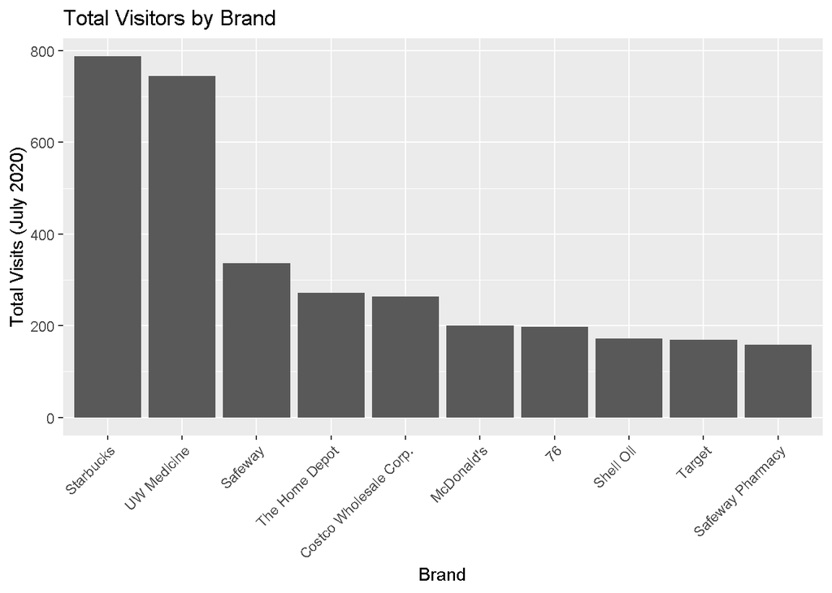

```r
ggplot(nw %>% slice(2:11),
       aes(x = reorder(brands,-visits), y = visits)) +
  stat_summary(geom = 'bar',
               fun = sum) +
  labs(x = 'Brand', y = 'Total Visits (July 2020)', title = 'Total Visitors by Brand') + theme(axis.text.x=element_text(angle = 45, hjust = 1))
```

The top 10 brands are similar to the ones we discovered for the overall Seattle area, however, the order is just different. In the overall Seattle area, Costco was one of the most phone visited brands through, however, in the Northwest, it is closer to the middle. We can see that people will typically visit the same brands no matter their location because they are staples to everyday life.